# Austin, TX: Housing Prices

Data Science 2 with R (STAT 301-2)

Author

Christine Jie

Published

March 10, 2024

**Github Repo Link**

https://github.com/stat301-2-2024-winter/final-project-2-christinejie

## Introduction

I wish to predict the sales price of houses in Austin, Texas using characteristics of the house including number of bedrooms, square feet, and whether the house has a garage.

My motivation for creating this model is because I truly enjoy browsing real estate websites in my free time. I have always been curious about the factors that influence the price of a home, including whether it has parking, number of bedrooms, square footage, and quality of local schools. As an economics major, I’m also aware that housing prices are a large reflection of the local economy.

I used a data set from Kaggle called [Austin, TX House Listings](https://www.kaggle.com/datasets/ericpierce/austinhousingprices). The data set that I chose consists of over 15,000 home listings, with 42 variables including both categorical and numerical variables.

## Data Overview

Table 1: Summary of All Variables Using Skim

(a) Data summary

| Name | house |
| --- | --- |
| Number of rows | 15171 |
| Number of columns | 42 |
| _______________________ |  |
| Column type frequency: |  |
| factor | 9 |
| numeric | 33 |
| ________________________ |  |
| Group variables | None |

**Variable type: factor**

| skim_variable | n_missing | complete_rate | ordered | n_unique | top_counts |
| --- | --- | --- | --- | --- | --- |
| city | 0 | 1 | FALSE | 9 | aus: 15020, del: 86, pfl: 36, dri: 12 |
| zipcode | 0 | 1 | FALSE | 48 | 787: 1144, 787: 1039, 787: 774, 787: 706 |
| has_association | 0 | 1 | FALSE | 2 | TRU: 8007, FAL: 7164 |
| has_cooling | 0 | 1 | FALSE | 2 | TRU: 14897, FAL: 274 |
| has_garage | 0 | 1 | FALSE | 2 | TRU: 8346, FAL: 6825 |
| has_heating | 0 | 1 | FALSE | 2 | TRU: 15022, FAL: 149 |
| has_spa | 0 | 1 | FALSE | 2 | FAL: 13972, TRU: 1199 |
| has_view | 0 | 1 | FALSE | 2 | FAL: 11716, TRU: 3455 |
| home_type | 0 | 1 | FALSE | 10 | Sin: 14241, Con: 470, Tow: 174, Mul: 96 |

**Variable type: numeric**

| skim_variable | n_missing | complete_rate | mean | sd | p0 | p25 | p50 | p75 | p100 |
| --- | --- | --- | --- | --- | --- | --- | --- | --- | --- |
| latitude | 0 | 1 | 30.29 | 0.10 | 30.09 | 30.20 | 30.28 | 30.37 | 30.52 |
| longitude | 0 | 1 | -97.78 | 0.08 | -98.02 | -97.84 | -97.77 | -97.72 | -97.57 |
| property_tax_rate | 0 | 1 | 1.99 | 0.05 | 1.98 | 1.98 | 1.98 | 1.98 | 2.21 |
| garage_spaces | 0 | 1 | 1.23 | 1.35 | 0.00 | 0.00 | 1.00 | 2.00 | 22.00 |
| parking_spaces | 0 | 1 | 1.22 | 1.35 | 0.00 | 0.00 | 1.00 | 2.00 | 22.00 |
| year_built | 0 | 1 | 1988.55 | 21.58 | 1905.00 | 1974.00 | 1993.00 | 2006.00 | 2020.00 |
| latest_price | 0 | 1 | 512767.74 | 453185.31 | 5500.00 | 309000.00 | 405000.00 | 575000.00 | 13500000.00 |
| num_price_changes | 0 | 1 | 3.03 | 2.49 | 1.00 | 1.00 | 2.00 | 4.00 | 23.00 |
| latest_salemonth | 0 | 1 | 6.73 | 3.15 | 1.00 | 4.00 | 7.00 | 9.00 | 12.00 |
| latest_saleyear | 0 | 1 | 2019.08 | 0.81 | 2018.00 | 2018.00 | 2019.00 | 2020.00 | 2021.00 |
| num_of_photos | 0 | 1 | 30.64 | 21.18 | 1.00 | 20.00 | 29.00 | 39.00 | 179.00 |
| num_of_accessibility_features | 0 | 1 | 0.01 | 0.18 | 0.00 | 0.00 | 0.00 | 0.00 | 8.00 |
| num_of_appliances | 0 | 1 | 3.47 | 1.89 | 0.00 | 2.00 | 3.00 | 4.00 | 12.00 |
| num_of_parking_features | 0 | 1 | 1.71 | 0.79 | 0.00 | 1.00 | 2.00 | 2.00 | 6.00 |
| num_of_patio_and_porch_features | 0 | 1 | 0.66 | 0.98 | 0.00 | 0.00 | 0.00 | 1.00 | 8.00 |
| num_of_security_features | 0 | 1 | 0.47 | 0.82 | 0.00 | 0.00 | 0.00 | 1.00 | 6.00 |
| num_of_waterfront_features | 0 | 1 | 0.00 | 0.06 | 0.00 | 0.00 | 0.00 | 0.00 | 2.00 |
| num_of_window_features | 0 | 1 | 0.21 | 0.49 | 0.00 | 0.00 | 0.00 | 0.00 | 4.00 |
| num_of_community_features | 0 | 1 | 0.02 | 0.21 | 0.00 | 0.00 | 0.00 | 0.00 | 8.00 |
| lot_size_sq_ft | 0 | 1 | 119083.97 | 12252718.78 | 100.00 | 6534.00 | 8276.00 | 10890.00 | 1508482800.00 |
| living_area_sq_ft | 0 | 1 | 2208.32 | 1378.58 | 300.00 | 1483.00 | 1975.00 | 2687.00 | 109292.00 |
| num_of_primary_schools | 0 | 1 | 0.94 | 0.24 | 0.00 | 1.00 | 1.00 | 1.00 | 2.00 |
| num_of_elementary_schools | 0 | 1 | 0.05 | 0.23 | 0.00 | 0.00 | 0.00 | 0.00 | 2.00 |
| num_of_middle_schools | 0 | 1 | 1.04 | 0.26 | 0.00 | 1.00 | 1.00 | 1.00 | 3.00 |
| num_of_high_schools | 0 | 1 | 0.98 | 0.29 | 0.00 | 1.00 | 1.00 | 1.00 | 2.00 |
| avg_school_distance | 0 | 1 | 1.84 | 1.07 | 0.20 | 1.10 | 1.57 | 2.27 | 9.00 |
| avg_school_rating | 0 | 1 | 5.78 | 1.86 | 2.33 | 4.00 | 5.78 | 7.00 | 9.50 |
| avg_school_size | 0 | 1 | 1237.30 | 326.51 | 396.00 | 966.00 | 1287.00 | 1496.00 | 1913.00 |
| median_students_per_teacher | 0 | 1 | 14.86 | 1.74 | 10.00 | 14.00 | 15.00 | 16.00 | 19.00 |
| num_of_bathrooms | 0 | 1 | 2.68 | 1.05 | 0.00 | 2.00 | 3.00 | 3.00 | 27.00 |
| num_of_bedrooms | 0 | 1 | 3.44 | 0.85 | 0.00 | 3.00 | 3.00 | 4.00 | 20.00 |
| num_of_stories | 0 | 1 | 1.47 | 0.52 | 1.00 | 1.00 | 1.00 | 2.00 | 4.00 |
| price_log10 | 0 | 1 | 5.63 | 0.24 | 3.74 | 5.49 | 5.61 | 5.76 | 7.13 |

From Table 1, there are no variables with any missingness issues. The variables `city`, `has_cooling` (has cooling), `has_heating` (has heating), `has_spa` (has spa) have class imbalance issues, which I addressed by removing them from my recipe.

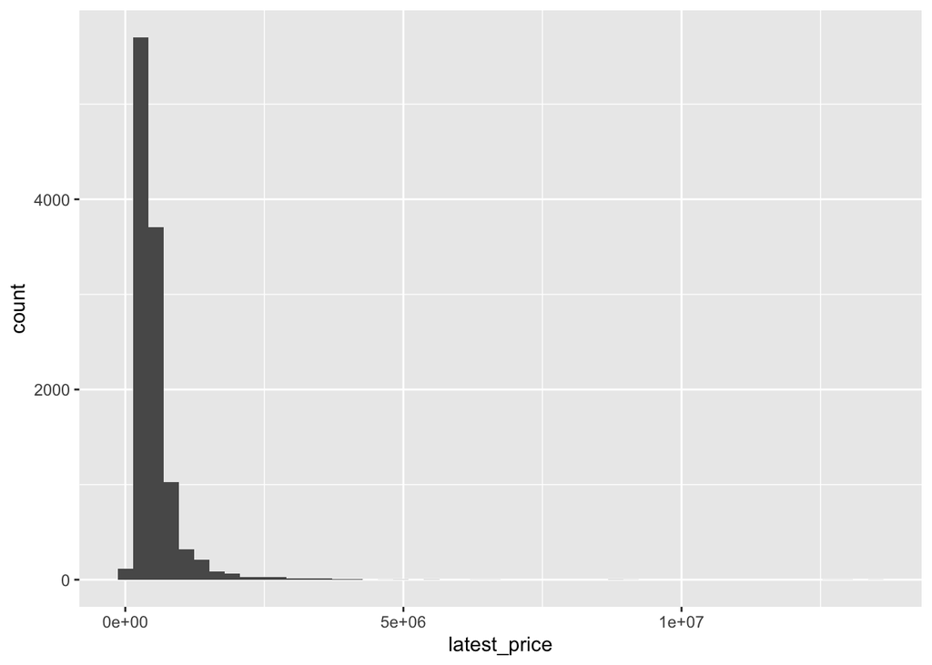

The `latest_price` variable my response variable. From this graph, we can see this variable is heavily right-skewed, so I decided to transform it using a log10 transformation.

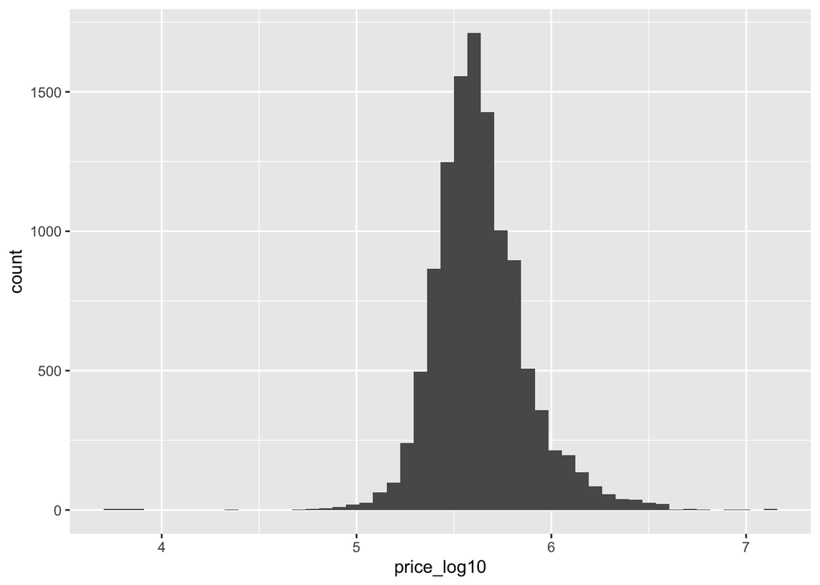

This is my new response variable that I will be working with for the rest of the project, `price_log10`, which is approximately normally distributed.

## Methods

**Overview** This is a regression and prediction problem because we are predicting house prices using a variety of variables.

**Data Splitting** I used 75% of the data for training the models and the remaining 25% for testing the models.

**Model Types**: I used the 6 following models:

1. Baseline: This is my most basic model.
2. Boosted Tree (bt): Boosted Trees work by putting together a bunch of decision trees, where each new tree is trained to correct the mistakes of the previous ones. Then, all these trees are added together to make the final prediction, with each tree’s contribution adjusted based on how much it helps improve the overall prediction.
3. Elastic Net (en): The Elastic Net model combines two types of penalties (Lasso and Ridge) to perform linear regression, using both feature selection (picking out the most important information from a bunch of data to make predictions) and coefficient shrinkage (preventing the model from overreacting to noisy data) for better prediction accuracy.
4. K - Nearest Neighbors (knn): The knn model selects a number of features for prediction, calculates the Euclidean distance between the new data point and each training point, and then finds the average value of the “K” closest data points for prediction.
5. Simple Linear (lm): the linear model describes the relationship between a dependent variable and independent variables with a straight line, determined by a slope and y-intercept, often estimated using the method of least squares.
6. Random Forest (rf): the random forest model creates many decision trees which are built on a random sample of the data, and features that are randomly chosen.Then, for predictions, it combines the results of all the trees, either by averaging them for numerical data or by picking the most popular choice for categorical data

**Tuning Parameters** Tuning a model adjusts its parameters to optimize its performance on a given dataset. This involves experimenting with different parameter values to find the combination that results in the lowest RMSE.

For the Boosted Tree model, I tuned the mtry, min_n and learn_rate parameters. Mtry is the number of sampled predictors, min_n is the number of data points to split, and learn_rate is weight for the influence of each new tree.

For the Elastic Net model, I tuned the penalty and mixture parameters. Penalty is a term added during training to discourage overfitting. Mixture controls whether the elastic model is more like a ridge model (mixture = 0) or more like a lasso model (mixture = 1).

For the Random Forest model, I tuned the min_n and mtry parameters. min_n is the number of data points to split and mtry is the number of sampled predictors.

For the K-Nearest Neighbors model, I tuned the neighbors parameter. neighbors is the number of nearest neighbors used when making predictions.

**Resampling** Resampling is when you choose random samples from the initial training dataset with replacement to estimate the population parameter repeatedly. I used v-fold cross validation with 10 folds and 5 repeats. This means the data was divided into 10 sets of equal size and we are fitting/training each model 50 times.

**Recipe Buiding** I built 4 recipes.

1. Standard kitchen sink recipe where I used all of the predictor variables.
2. Standard Feature Engineered recipe where I removed variables that had only a few levels which had little predictive power or severe class imbalance issues. I also interacted the variables for number of bathrooms and number of bedrooms to account for dependencies between these variables. (See appendix for EDA)
3. Tree based kitchen sink recipe where I used all of the predictor variables.
4. Tree based Feature Engineered recipe where I removed variables that had only a few levels which had little predictive power or severe class imbalance issues.

**Evaluation Metric** The metric that was used to compare models was root mean squared error, or RMSE. RMSE measures the average deviation of the predicted values from the actual values in the dataset.

## Model Building and Selection

**Evaluation Metric** RMSE will be used to compare the models, which measures the average deviation of the predicted values from the actual values in the dataset. A lower RMSE means greater accuracy.

**Table of Best Performing Model Results**

Table 2: RMSE and Standard Error of Best Performing Models

| Model Type | RMSE | Standard Error |
| --- | --- | --- |
| RF FE | 0.125 | 0.0022 |
| RF KS | 0.127 | 0.0022 |
| BT KS | 0.133 | 0.0022 |
| BT FE | 0.136 | 0.0022 |
| KNN KS | 0.147 | 0.0019 |
| EN KS | 0.151 | 0.0052 |
| KNN FE | 0.158 | 0.0018 |
| Linear KS | 0.161 | 0.0070 |
| EN FE | 0.185 | 0.0022 |
| Baseline KS | 0.240 | 0.0013 |
| Baseline FE | 0.240 | 0.0013 |
| Linear FE | 3.039 | 0.7796 |

From Table 2, we can see the RMSE and standard error of each model with each recipe.

The best model is the one with the lowest RMSE. Here, it is the random forest model using the tree based feature engineered recipe.

The worst model is the one with the highest RMSE. Here, it is the linear model using the standard feature engineered recipe.

**Best Parameters for Each Model**

Table 3: Best Performing Parameters for Each Model

| model | mtry | min_n | learn_rate | neighbors | penalty | mixture |
| --- | --- | --- | --- | --- | --- | --- |
| Boosted Tree | 7 | 21 | 0.631 | NA | NA | NA |
| KNN | NA | NA | NA | 15 | NA | NA |
| Random Forest | 7 | 2 | NA | NA | NA | NA |
| Elastic Net | NA | NA | NA | NA | 0.178 | 0 |

From Table 3, we can see the best performing parameters for each model.

For boosted tree, the best model (with lowest RMSE) had the parameters of mtry = 7, min_n = 21, and learn_rate = 0.631.

For KNN, the best model (with lowest RMSE) had the parameter of neighbors = 15.

For random forest, the best model (with lowest RMSE) had the parameters of mtry = 7 and min_n = 2.

For elastic net, the best model (with lowest RMSE) had the parameters of penalty = 0.178 and mixture = 0.

**Final Winning Model**

This was not surprising that this particular model and recipe won, because random forest has usually been the winning model in previous labs, and feature engineered recipes are intended to be more accurate than a kitchen sink recipe.

## Final Model Analysis

After fitting the winning random forest model with feature engineered recipe to the testing data, I obtained the following results.

**Results of Final Model in Log Base 10**

Table 4: RMSE, RSQ, MAE of Final Model in Log Base 10

| .metric | .estimate |
| --- | --- |
| rmse | 0.114 |
| rsq | 0.759 |
| mae | 0.071 |

From Table 4, we can see the RMSE, RSQ, MAE of the final winning model in Log Base 10.

The RMSE measures the average magnitude of difference between values predicted by a model and the actual values. Here, the RMSE is 0.114 which means the average magnitude of difference between predicted and actual log10(price) is 0.114. This is much lower and better than the baseline model, which had a RMSE of 0.240. This means that building a predictive model did pay off.

RSQ represents the proportion of the variation in the dependent variable that is explained by the independent variables. Here the RSQ is 0.759 so 75.9% of the variation in log10(price) was explained by the predictor variables.

MAE represents the average absolute difference between predicted values and the actual values. Here, the MAE is 0.071, which means on average there is a 0.071 difference in predicted versus actual log10(price).

**Results of Final Model in Original Scale**

Table 5: RMSE, RSQ, MAE of Final Model in Original Scale

| .metric | .estimate |
| --- | --- |
| rmse | 226587.631 |
| rsq | 0.725 |
| mae | 91211.575 |

From Table 5, we can see the RMSE, RSQ, MAE of the final winning model in the original scale.

The RMSE measures the average magnitude of difference between values predicted by a model and the actual values. Here, the RMSE is 226587 which means the average magnitude of difference between predicted and actual price is $226,587.

RSQ represents the proportion of the variation in the dependent variable that is explained by the independent variables. Here the RSQ is 0.725 so 72.5% of the variation in price was explained by the predictor variables.

MAE represents the average absolute difference between predicted values and the actual values. Here, the MAE is 91211 which means on average there is a $91,211 difference in predicted versus actual price.

**Graphs of Predicted Prices vs Actual Prices**

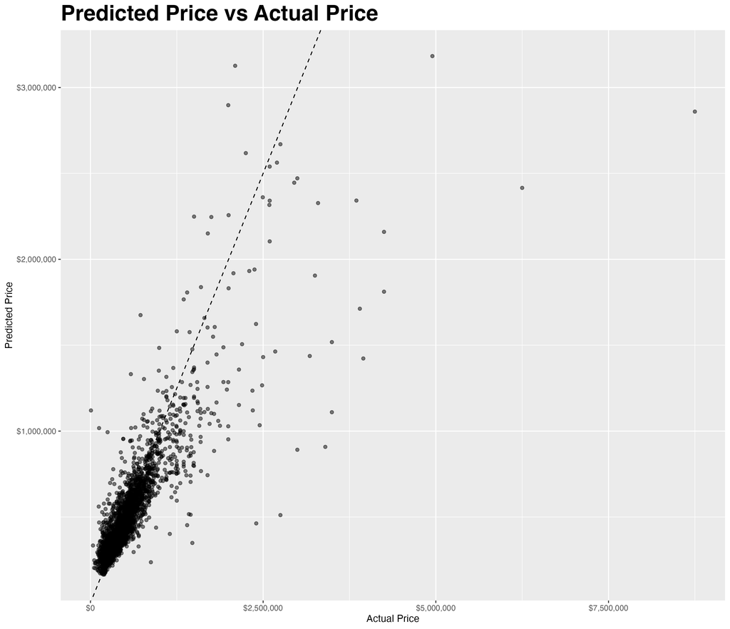

This graph shows the relationship between predicted and actual price, for houses of all prices. For the most part, predicted price and actual price are pretty similar, as visualized by this graph. This means the model did a decent job at predicting house prices, overall.

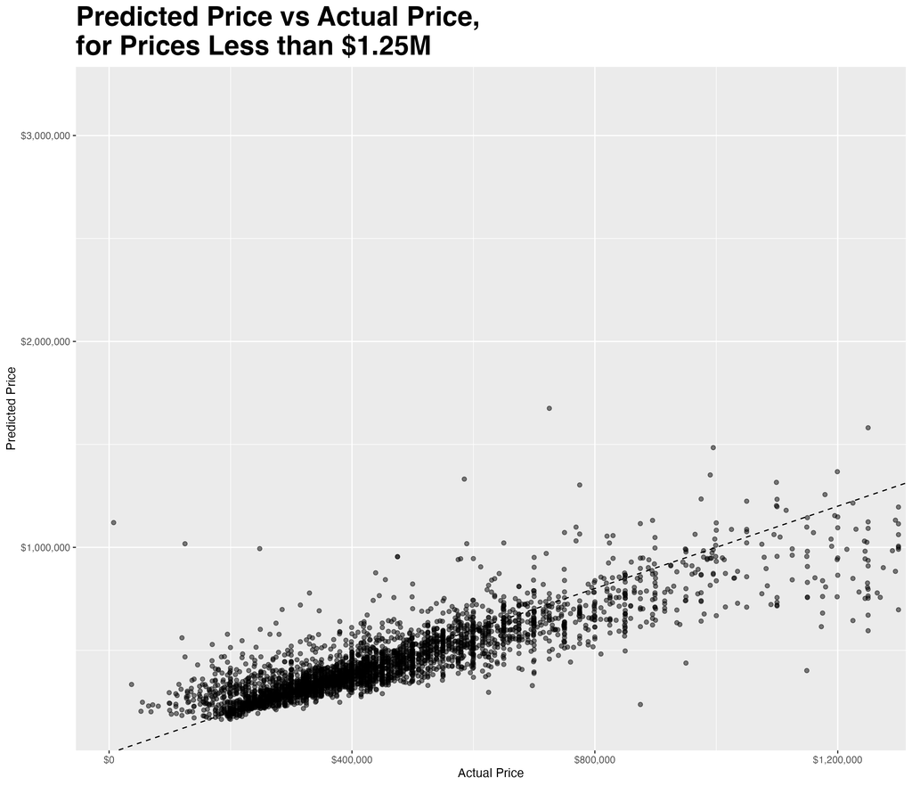

This graph shows the relationship between predicted and actual price, for houses less than $1.25M. Most of the data points are on the line of best fit. This means the model did a good job at predicting price, especially for properties that were less than around $1,250,000.

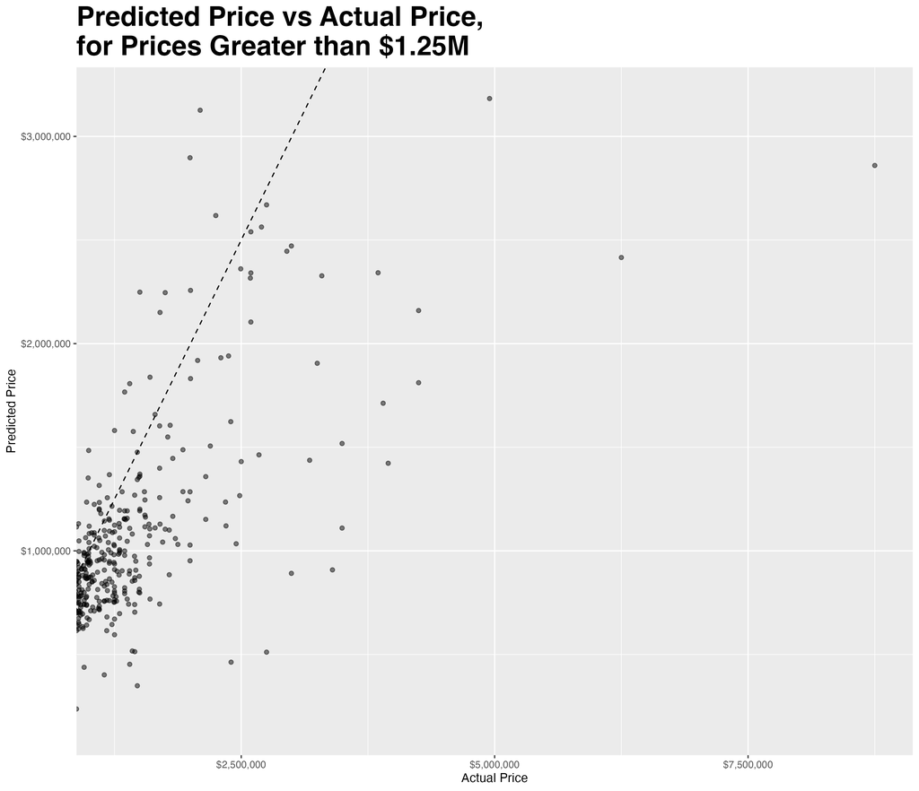

This graph shows the relationship between predicted and actual price, for houses more than $1.25M. Many of the data points are not on the line of best fit. This means the model was less accurate at predicting houses with higher prices. There are a few very high outliers of actual price ($5M+) that are very far from the line of best fit, which can be seen on the far right side of the graph.

## Conclusion

**Assessing and Interpreting Accuracy of Winning Model**

Although my winning model was the best out of all of the models I built and compared, the winning RMSE was still large.

The winning model, when evaluated in its original scale, had a RMSE of 226587, which means the average magnitude of difference between predicted and actual price is $226,587. This was in part due to many of the high priced homes, which the winning model was less accurate at predicting than lower priced homes.

I believe this is a large average magnitude of difference between predicted and actual prices. If I were a real estate agent or homebuyer using this model to evaluate house prices, an average $200,000+ discrepancy is a big deal.

However, as stated above, the model was more accurate for lower priced homes than higher priced homes.

**Next Steps**

To improve the performance of my model, I would create two separate models: one for predicting lower priced houses, and one for predicting higher priced houses.

I hypothesize higher priced houses are luxury houses with higher quality features that are not captured well by any of the existing predictor variables. For example, better finishes, fixtures, and the overall quality of the house are not represented in my current data set.

I believe my hypothesis makes sense. With a quick look at Zillow listings, I can immediately see that houses with luxury features such as heated floors and granite countertops typically command a higher price per square feet and higher price per number of bedrooms, among other factors.

## References

Pierce, E. (2021). Austin, TX House Listings. Kaggle.com. https://www.kaggle.com/datasets/ericpierce/austinhousingprices

## Appendix: EDA

**Correlation Plot for All Numeric Variables**

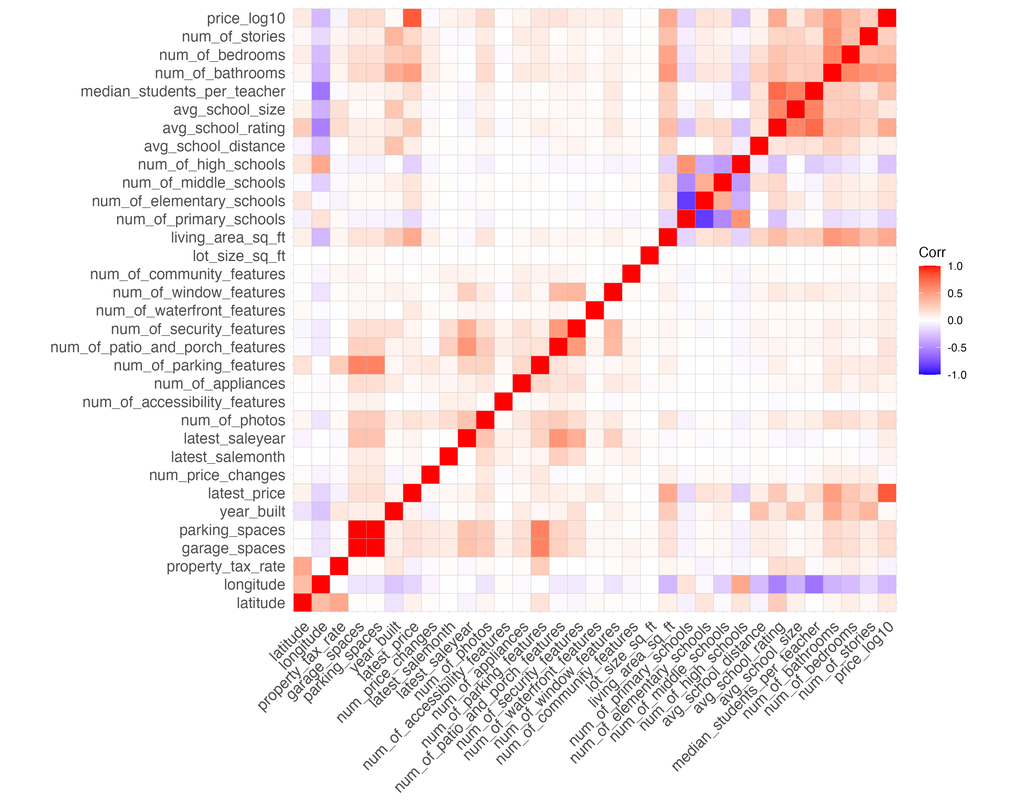

This plot shows the correlation between all numeric variables. In my recipe, I decided to remove `year_built` (year built), `num_price_changes` (number of price changes), `num_of_accessibility_features` (number of accessibility features), `num_of_community_features` (number of community features). This is because these variables had close to zero correlation with the outcome variable of interest, `price_log10` (price transformed in log10).

**Removal of Categorical Variables**

I also removed the categorical variables `city` (city), `zipcode` (zipcode), and `home_type`(home type) because these variables had 9, 48, and 10 unique values respectively. These variables had little predictive power because there were not enough unique values, so I removed them. See Data Overview section above.

**Interaction Terms**

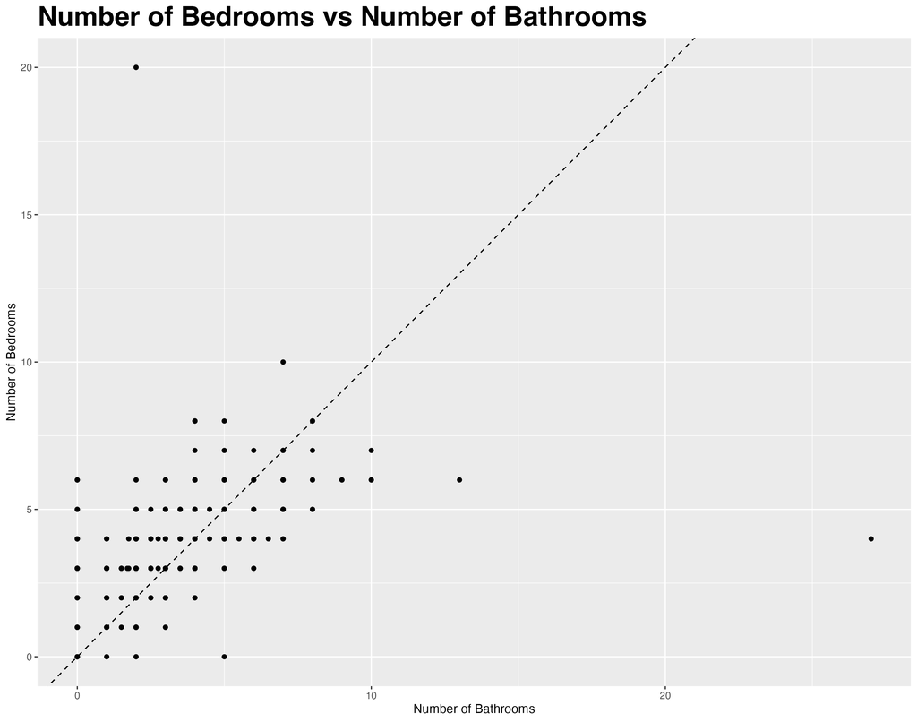

This graph shows the relationship between number of bedrooms and number of bathrooms. There is a strong positive relationship here, as number of bathrooms increases, number of bedrooms increases too. I used `step_interact()` in my recipe, with number of bathrooms and number of bedrooms as interaction terms.